# 학생 성공 관련 지표

Kibum Moon

Nov.26.2019

# 연구 방법

## 분석 대상

다양성 분석은 분석의 목적과 범위에 따라 다양한 요소를 고려해 진행된다. 대학의 다양성 분석을 수행하기 위해 교내 구성원과 각각의 구성원을 구분하는 속성(요소)을 고려할 수 있다. 이때 교내 구성원은 학생, 교원, 직원 등 대학 공동체를 구성하는 모든 사람들이 대상이 될 수 있다. 성별, 국적, 나이, 전공 등은 각 구성원을 구분하는 요소가 된다. 본 연구에서는 다양성 분석이 적용될 수 있는 대표적인 사례로 학생의 국적을 고려한 다양성 분석을 실시했다. 2006년부터 2019년까지 입학한 서울 캠퍼스 외국인 학생 4315명의 자료를 분석에 사용했다. 해석적 의미를 분명히 하기 위해 편입을 통해 입학한 0명의 자료는 분석에서 제외했다.

# 연구 결과

## 외국인 학생 현황

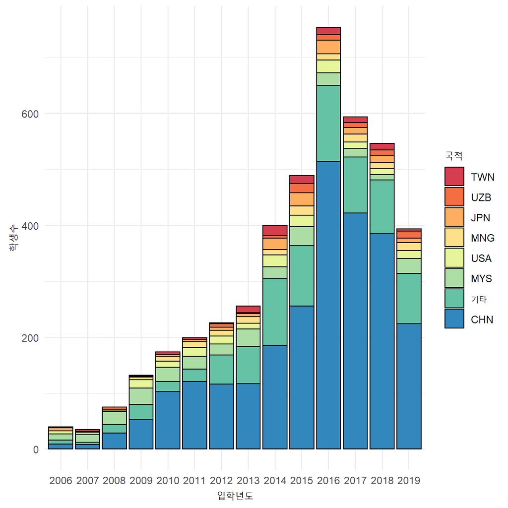

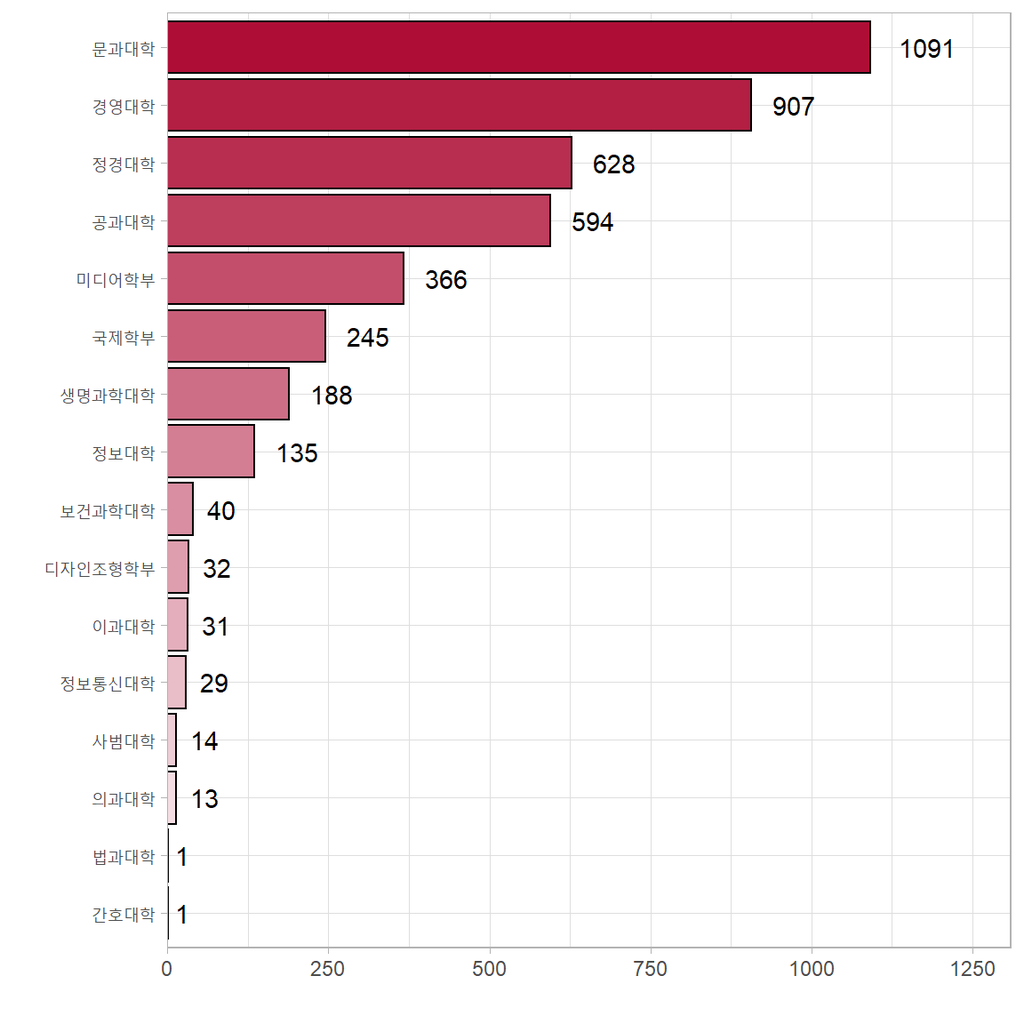

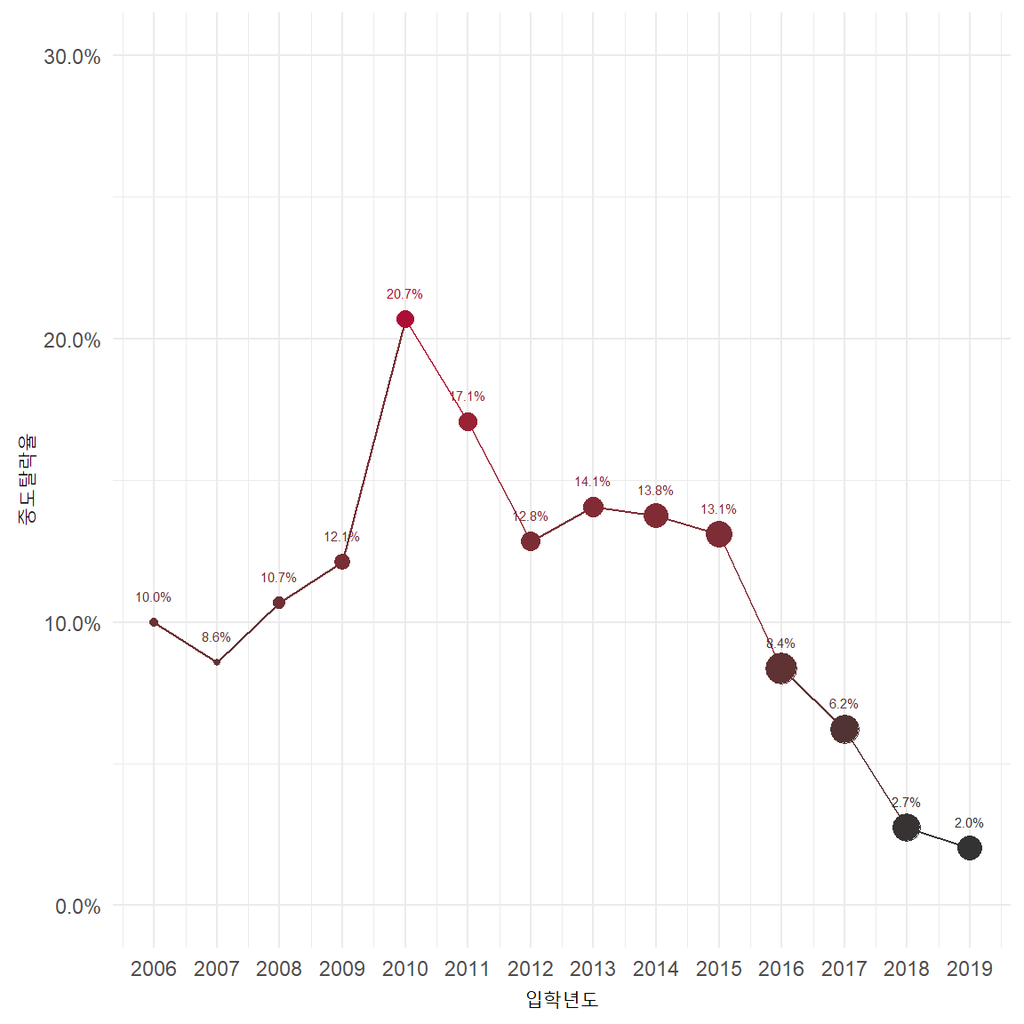

| 입학전형 | n | 비율(%) |
| --- | --- | --- |
| 외국인 | 4255 | 98.61 |
| Global KU | 25 | 0.58 |
| 정시_수능 | 20 | 0.46 |
| 수시_특기자 | 6 | 0.14 |
| 글로벌인재 | 4 | 0.09 |
| 순수정원외(=12년과정) | 2 | 0.05 |
| 12년과정 | 1 | 0.02 |
| 3년과정 | 1 | 0.02 |
| 수시_기회균등 | 1 | 0.02 |

## 다종성(variety) 분석

다종성은 한 생태계를 구성하는 종이 얼마나 다양한지 의미하는 개념이다. 다종성 분석은 해당 년도에 입학한 외국인 유학생의 국적이 얼마나 다양한가 보여준다. 외국인 유학생의 국적 다종성은 2016년 56개국으로 정점을 찍은 후 감소하는 추세이다. 하지만 2019년 외국인 유학생의 수가 정점 대비 52.25%에 불과한 반면 다종성은 정점 대비 80.36%으로 다종성의 감소폭이 학생수의 감소폭에 비해 상대적으로 작았다는 것을 보여준다.

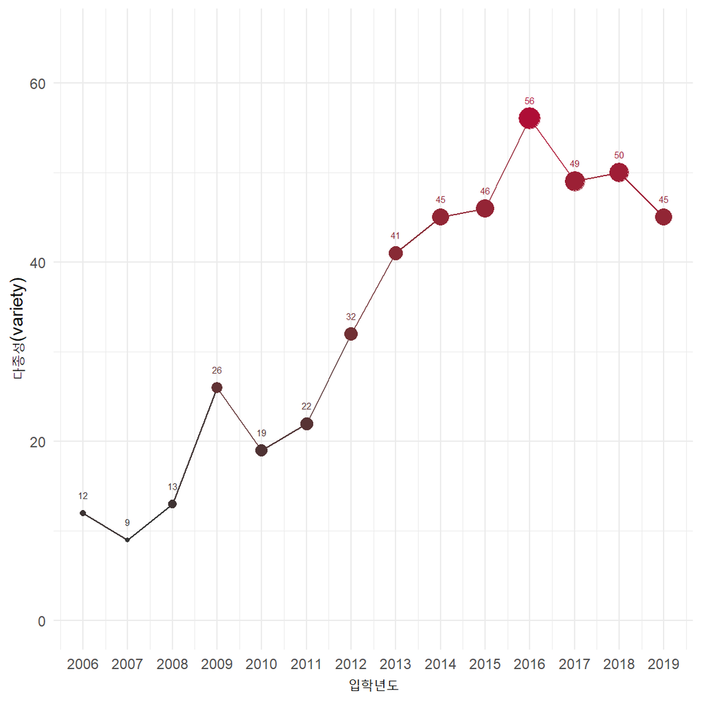

## 균등성(balance) 분석

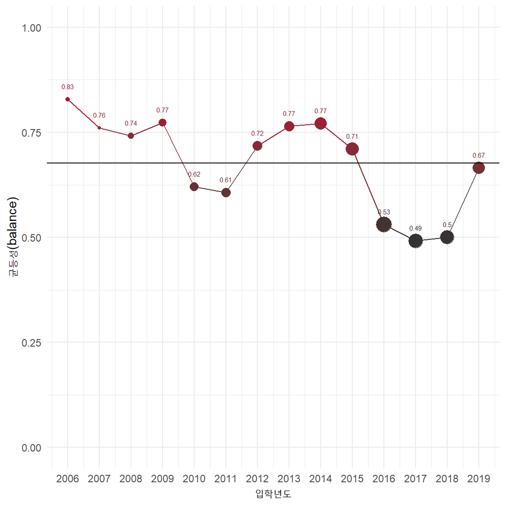

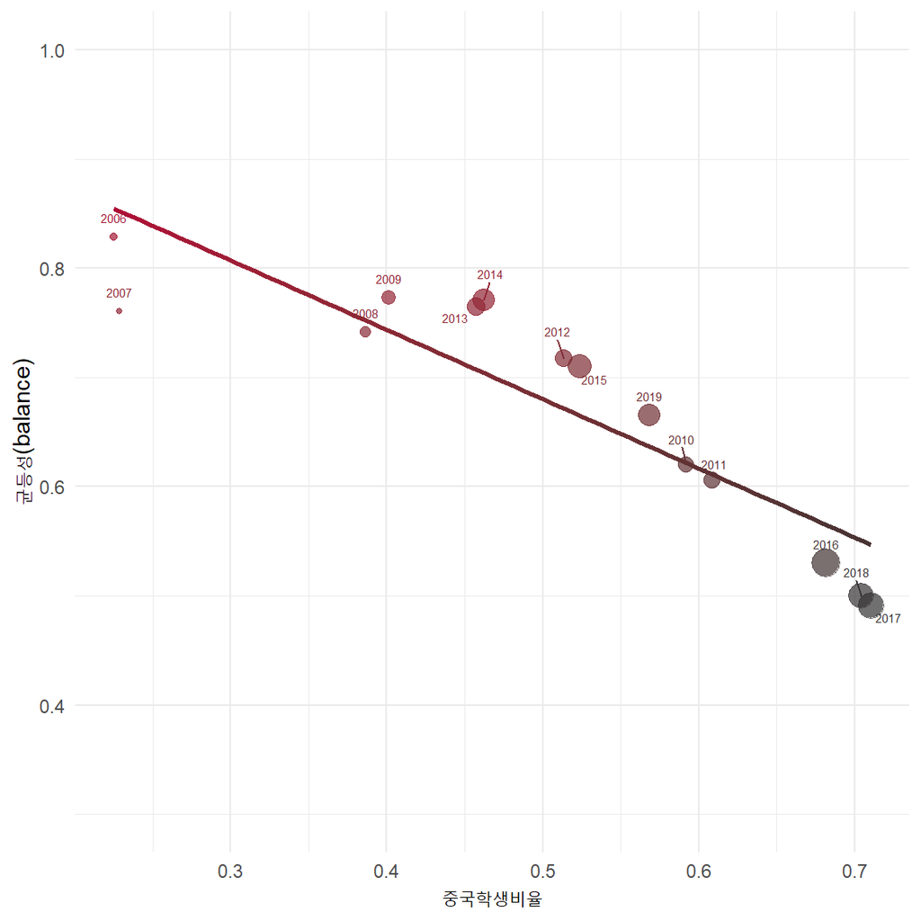

이러한 결과는 외국인 유학생의 절대적인 수가 늘어도 다양성이 늘지 않을 수 있다는 것을 보여준다. 특히 2016년부터 2018년 사이에는 외국인 학생의 수가 가장 많았음에도 불구하고 균등성 지수는 가장 낮았다. 따라서 외국인 학생의 질적 다양성을 높이기 위해서는 현재 중국에 편중된 외국인 학생의 출신국을 다변화 할 필요가 있어 보인다. 이를 위해 지역별 학생수 변화에 대한 분석을 진행했다. 중국과 일본을 포함한 동아시아 지역 출신의 학생수가 가장 빠르게 늘고 있다, B = 36.31, *p* < .001. 그림 6은 동아시아 지역 이외에 학생수가 늘고 있는 지역을 보여준다. 중앙 아시아 지역이 조사 기간 내 학생수 증가폭이 가장 컸다, B = 2.10, *p* = .001. 동남 아시아 지역은 동아시아를 제외하고 가장 많은 학생이 유입되었을 뿐만 아니라 그 증가폭 또한 컸다, B = 1.91, *p* = .002. 이런 점에서 중앙 아시아와 동남 아시아 출신 학생들의 유입이 증가하는 원인을 파악하는 것이 출신 지역 다변화에 도움이 될 수 있을 것으로 보인다. 한편, 북아메리카와 서아시아 지역은 2016년 경까지 학생수 증가폭이 컸지만 이후 학생 유입량이 급감하는 것으로 나타난다. 해당 지역으로부터의 학생 유입을 방해하는 요인에 대한 분석이 필요할 것이다.

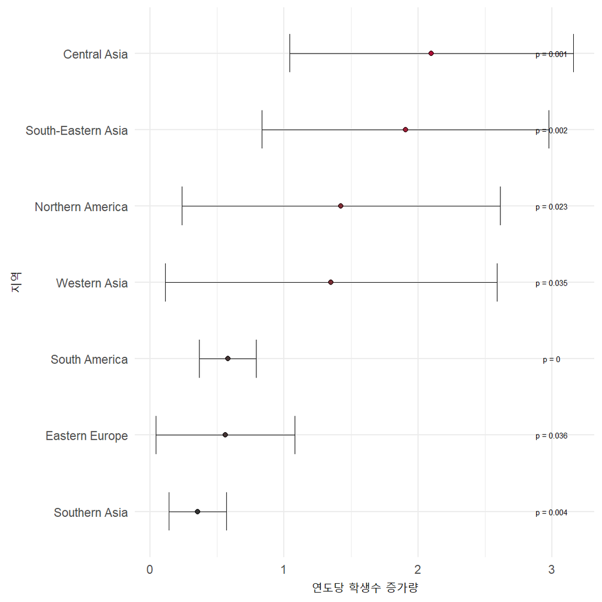

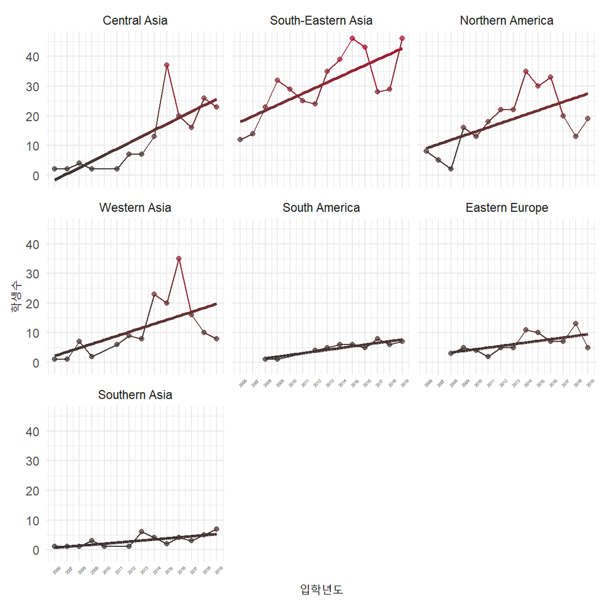

## 상이성(disparity) 분석

상이성은 한 생태계가 얼마나 이질적인 종들로 이루어져 있는 지 의미한다. 생태계를 구성하는 종의 수가 많고 각 종 간의 이질성이 높을수록 생태계의 상이성이 높아진다. 고려대학교 외국인 학생의 상이성 분석은 외국인 학생들의 출신국이 얼마나 다른 지를 보여준다. 상이성을 측정하기 위한 기준은 다양할 수 있다. 예를 들어 각 국가 간의 지리적 거리(Mayer, Thierry, Zignago, Soledad)나 문화적 거리(De Santis, Gustavo, Maltagliati, Mauro, Salvini, Silvana) 등이 외국인 학생들의 출신국 사이의 거리를 평가하기 기준이 될 수 있다. 또, 각 교내 학생 활동 데이터를 바탕으로 출신국 간의 거리를 산출할 수도 있다. 본 연구에서는 해석적 의미가 가장 명확한 국가간 지리적 거리를 상이성 산출의 기준으로 사용했다. 그림 8은 연도별 상이성의 변화를 보여준다. 각 상이성 점수는 해당 년도에 입학한 외국인 학생들의 출신국 간 지리적 거리를 모두 더한 값이다. 2016년의 상이성이 가장 높았다. 하지만 그림 9는 상이성 지수의 한계를 보여준다. 상이성 지수는 종의 분포를 고려하지 않기 때문에 종의 수가 많아질수록 그에 비례해 커지게 된다, *r* = .99, *p* < .001. 이러한 과정에서 생태계 내 개체의 대부분을 차지하는 종과 단 하나의 개체가 존재하는 종 사이의 비중이 반영되지 않게 된다.

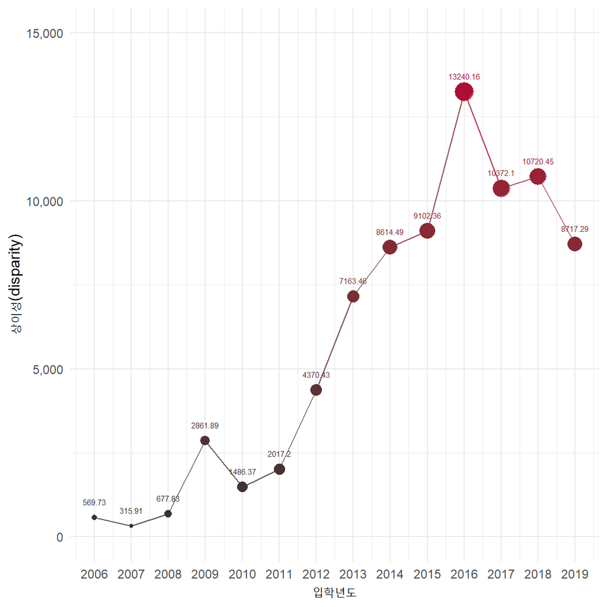

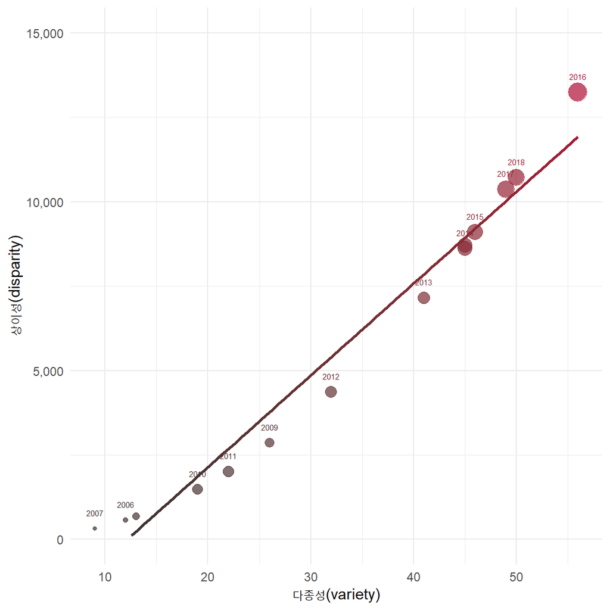

## 다양성(diversity) 분석

다양성은 균등성과 가중치를 모두 고려한 개념이다. 다양성 지수는 서로 이질적인 종들이 얼마나 고르게 분포하는 지를 종합적으로 보여준다. 고려대학교 외국인 학생의 다양성 분석은 얼마나 다양한 국적의 학생들이 고르게 분포하는 지 보여준다. 상이성 분석에서 개체의 비중이 고려되지 않은 것과 다르게 다양성 분석에서는 특정 국가 출신의 외국인 학생의 비율이 높을수록 다양성에 미치는 영향력이 커진다. 반면에 소수의 학생이 존재하는 국가는 그 국가가 다른 국가들과 이질적이어도 전체 다양성에 미치는 영향력은 작게 된다. 그림 10은 연도별 다양성 지수 변화를 보여준다. 다양성 분석 결과는 외국인 유학생의 양적 증가가 다양성 증가로 이어지지 않을 수 있다는 것을 다시 한 번 보여준다. 2019에는 전년 대비 외국인 학생의 수는 감소하였지만 다양성은 오히려 증가한 것을 확인할 수 있다. 다양성 지수 역시 중국 학생 비율과 밀접하게 관련되어 있는 것으로 나타났다, *r* = -.91, *p* < .001.

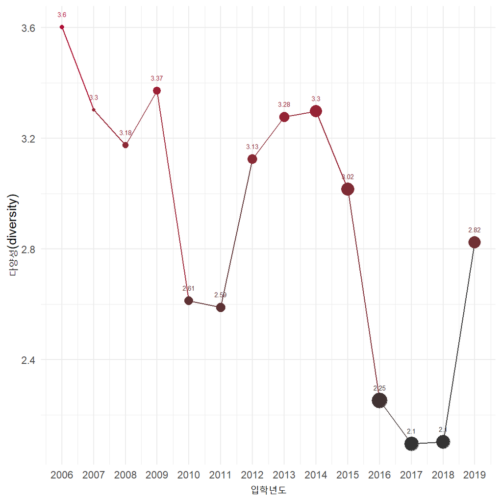

## 다양성 최적 균형점(optimal balance) 분석

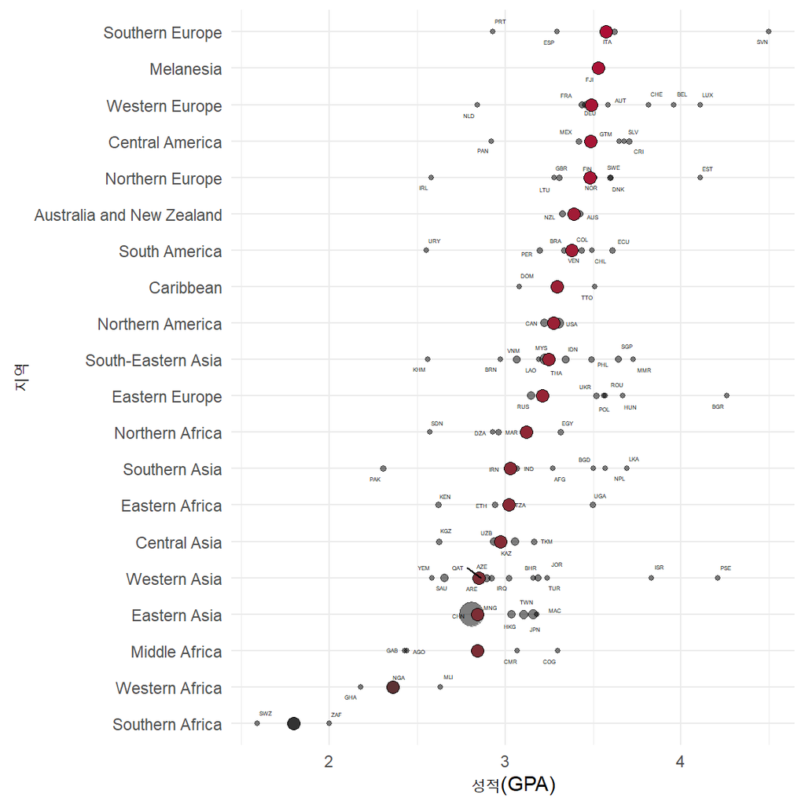

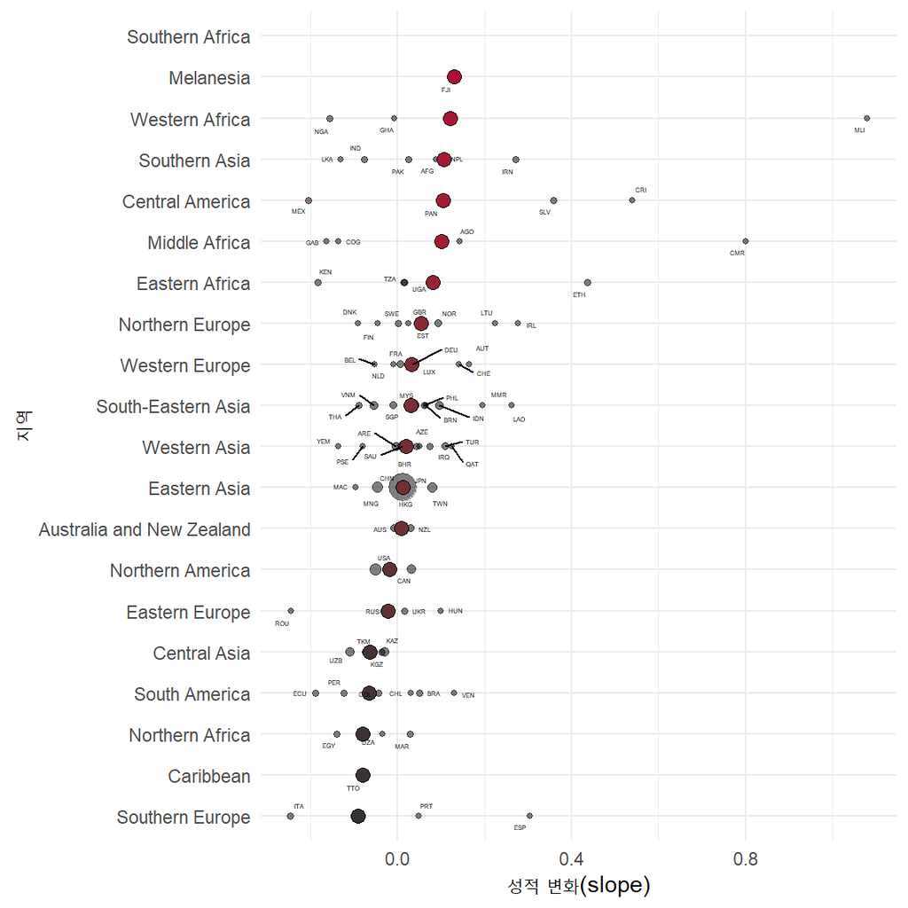

그림13은 수행 수준/다양성 트레이드오프에 따른 국적별 구성의 변화를 보여준다. 트레이드오프가 작을수록 수행 수준이 중시되어 말레이시아, 케나다 출신들의 비중이 높아진다. 트레이드오프가 커질수록 다양성이 더 중요하게 고려된다.

| 국적 | 평균_GPA | 평균_성적향상률 |
| --- | --- | --- |
| Malaysia | 3.227939 | 0.0351766 |
| Canada | 3.223662 | 0.0322217 |
| Taiwan | 3.103871 | 0.0787923 |
| United States | 3.303287 | -0.0506367 |
| Japan | 3.161367 | 0.0170540 |
| Russia | 3.147288 | -0.0232851 |
| Kazakhstan | 3.056667 | -0.0304881 |
| China | 2.810462 | 0.0126186 |
| Mongolia | 2.837870 | -0.0455386 |
| Uzbekistan | 2.938088 | -0.1099307 |
| Saudi Arabia | 2.653710 | 0.0106832 |

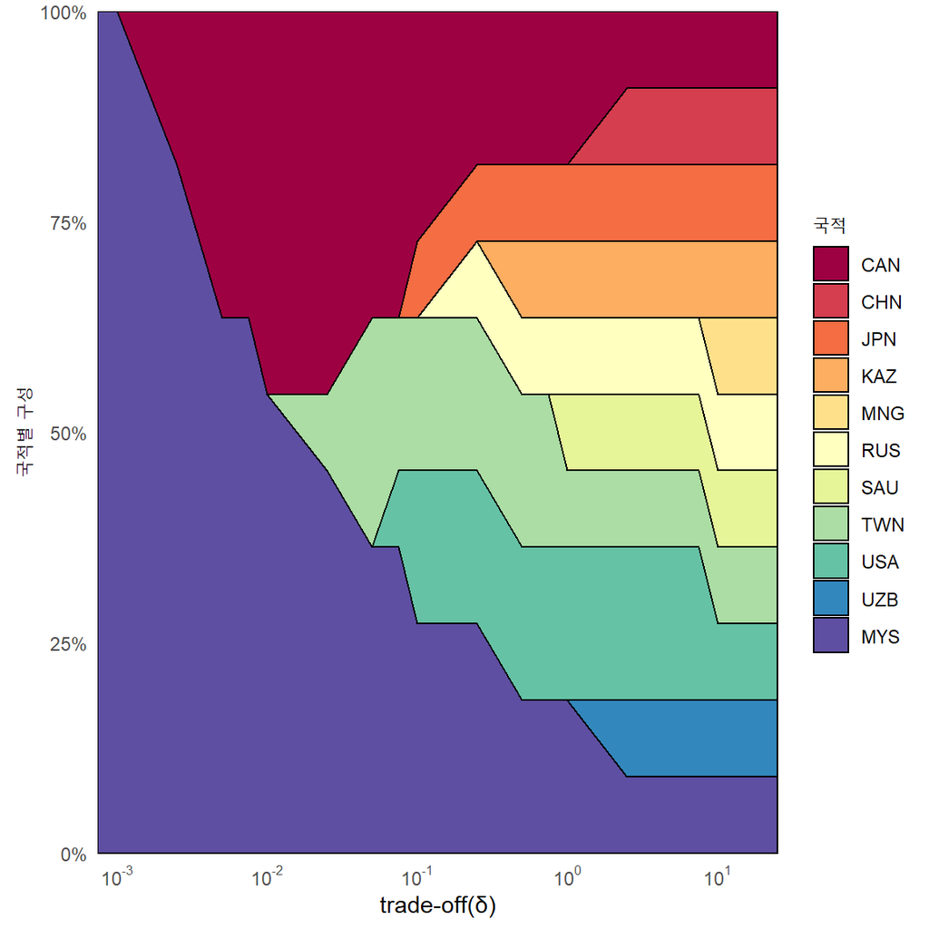

성적은 한 학생의 학업적 성취도와 관련된 기본적인 지표이다. 성적과 관련해 구체적으로 살펴볼 수 있는 지표는 총평점(GPA)과 성적 변화도, 성적우수 표창, 성적경고 등이 있다. 총평점과 성적 변화도는 한 학생의 전반적인 학업적 성취도를 보여준다. 성적우수 표창 및 성적경고는 각각 뛰어난 학업적 역량과 취약성을 보여준다.